# An example cleaning script

Andreas Handel

10/28/2021

# Processing script

This contains the same code and comments/information as processingscript.R

This just shows it as Rmd file, to give you an idea how to do it in either setup.

# Setup

Load needed packages. make sure they are installed.

```r
library(readxl) #for loading Excel files
library(dplyr) #for data processing/cleaning
library(tidyr) #for data processing/cleaning
library(skimr) #for nice visualization of data
library(here) #to set paths
```

# Data loading

Note that for functions that come from specific packages (instead of base R), I often specify both package and function like so: package::function() that’s not required one could just call the function specifying the package makes it clearer where the function “lives”, but it adds typing. You can do it either way.

```r
# path to data
# note the use of the here() package and not absolute paths
data_location <- here::here("data","raw_data","exampledata.xlsx")
rawdata <- readxl::read_excel(data_location)
```

# Check data

Several ways of looking at the data

```r
dplyr::glimpse(rawdata)
```

```
## Rows: 14
## Columns: 3
## $ Height <chr> "180", "175", "sixty", "178", "192", "6", "156", "166", "155", ~
## $ Weight <dbl> 80, 70, 60, 76, 90, 55, 90, 110, 54, 7000, NA, 45, 55, 50
## $ Sex    <chr> "M", "M", "F", "F", "NA", "F", "M", "M", "F", "M", "F", "F", "M~
```

```r
summary(rawdata)
```

```
##     Height              Weight           Sex
##  Length:14          Min.   :  45.0   Length:14
##  Class :character   1st Qu.:  55.0   Class :character
##  Mode  :character   Median :  70.0   Mode  :character
##                     Mean   : 602.7
##                     3rd Qu.:  90.0
##                     Max.   :7000.0
##                     NA's   :1
```

```r
head(rawdata)
```

```
## # A tibble: 6 x 3
##   Height Weight Sex
##   <chr>   <dbl> <chr>
## 1 180        80 M
## 2 175        70 M
## 3 sixty      60 F
## 4 178        76 F
## 5 192        90 NA
## 6 6          55 F
```

```r
skimr::skim(rawdata)
```

Data summary

| Name | rawdata |
| --- | --- |
| Number of rows | 14 |
| Number of columns | 3 |
| _______________________ |  |
| Column type frequency: |  |
| character | 2 |
| numeric | 1 |
| ________________________ |  |
| Group variables | None |

**Variable type: character**

| skim_variable | n_missing | complete_rate | min | max | empty | n_unique | whitespace |
| --- | --- | --- | --- | --- | --- | --- | --- |
| Height | 0 | 1 | 1 | 5 | 0 | 13 | 0 |
| Sex | 0 | 1 | 1 | 2 | 0 | 3 | 0 |

**Variable type: numeric**

| skim_variable | n_missing | complete_rate | mean | sd | p0 | p25 | p50 | p75 | p100 | hist |
| --- | --- | --- | --- | --- | --- | --- | --- | --- | --- | --- |
| Weight | 1 | 0.93 | 602.69 | 1922.25 | 45 | 55 | 70 | 90 | 7000 | ▇▁▁▁▁ |

Looks like we have the following data:

- height (seems like it’s in centimeters)
- weight (seems to be in kilogram)
- Sex

# Cleaning

By inspecting the data as done above, we find some problems that need addressing:

First, there is an entry for height which says “sixty” instead of a number. Does that mean it should be a numeric 60? It somehow doesn’t make sense since the weight is 60kg, which can’t happen for a 60cm person (a baby). Since we don’t know how to fix this, we might decide to remove the person. This “sixty” entry also turned all Height entries into characters instead of numeric. That conversion to character also means that our summary function isn’t very meaningful. So let’s fix that first.

```r
d1 <- rawdata %>% dplyr::filter( Height != "sixty" ) %>%
                  dplyr::mutate(Height = as.numeric(Height))
skimr::skim(d1)
```

Data summary

| Name | d1 |
| --- | --- |
| Number of rows | 13 |
| Number of columns | 3 |
| _______________________ |  |
| Column type frequency: |  |
| character | 1 |
| numeric | 2 |
| ________________________ |  |
| Group variables | None |

**Variable type: character**

| skim_variable | n_missing | complete_rate | min | max | empty | n_unique | whitespace |
| --- | --- | --- | --- | --- | --- | --- | --- |
| Sex | 0 | 1 | 1 | 2 | 0 | 3 | 0 |

**Variable type: numeric**

| skim_variable | n_missing | complete_rate | mean | sd | p0 | p25 | p50 | p75 | p100 | hist |
| --- | --- | --- | --- | --- | --- | --- | --- | --- | --- | --- |
| Height | 0 | 1.00 | 151.62 | 46.46 | 6 | 154.00 | 165 | 175 | 192 | ▁▁▁▂▇ |
| Weight | 1 | 0.92 | 647.92 | 2000.48 | 45 | 54.75 | 73 | 90 | 7000 | ▇▁▁▁▁ |

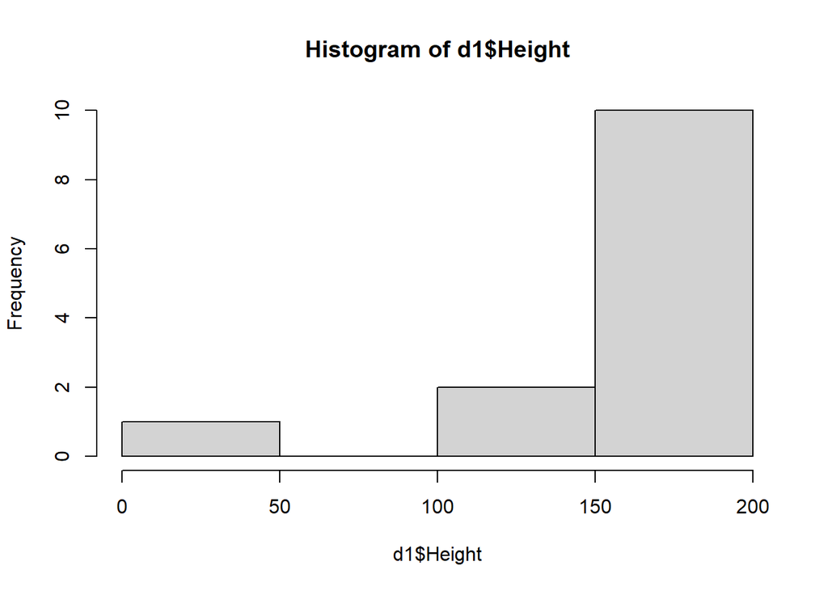

```r
hist(d1$Height)
```

Now we see that there is one person with a height of 6. That could be a typo, or someone mistakenly entered their height in feet. Since we unfortunately don’t know, we might need to remove this person, which we’ll do here.

```r
d2 <- d1 %>% dplyr::filter(Height != 6)
skimr::skim(d2)
```

Data summary

| Name | d2 |
| --- | --- |
| Number of rows | 12 |
| Number of columns | 3 |
| _______________________ |  |
| Column type frequency: |  |
| character | 1 |
| numeric | 2 |
| ________________________ |  |
| Group variables | None |

**Variable type: character**

| skim_variable | n_missing | complete_rate | min | max | empty | n_unique | whitespace |
| --- | --- | --- | --- | --- | --- | --- | --- |
| Sex | 0 | 1 | 1 | 2 | 0 | 3 | 0 |

**Variable type: numeric**

| skim_variable | n_missing | complete_rate | mean | sd | p0 | p25 | p50 | p75 | p100 | hist |
| --- | --- | --- | --- | --- | --- | --- | --- | --- | --- | --- |
| Height | 0 | 1.00 | 163.75 | 16.33 | 133 | 154.75 | 165.5 | 175.75 | 192 | ▂▇▆▆▂ |
| Weight | 1 | 0.92 | 701.82 | 2088.97 | 45 | 54.50 | 76.0 | 90.00 | 7000 | ▇▁▁▁▁ |

Height values seem ok now.

Now let’s look at the `Weight` variable. There is a person with weight of 7000, which is impossible, and one person with missing weight. To be able to analyze the data, we’ll remove those individuals as well.

```r
d3 <- d2 %>%  dplyr::filter(Weight != 7000) %>% tidyr::drop_na()
skimr::skim(d3)
```

Data summary

| Name | d3 |
| --- | --- |
| Number of rows | 10 |
| Number of columns | 3 |
| _______________________ |  |
| Column type frequency: |  |
| character | 1 |
| numeric | 2 |
| ________________________ |  |
| Group variables | None |

**Variable type: character**

| skim_variable | n_missing | complete_rate | min | max | empty | n_unique | whitespace |
| --- | --- | --- | --- | --- | --- | --- | --- |
| Sex | 0 | 1 | 1 | 2 | 0 | 3 | 0 |

**Variable type: numeric**

| skim_variable | n_missing | complete_rate | mean | sd | p0 | p25 | p50 | p75 | p100 | hist |
| --- | --- | --- | --- | --- | --- | --- | --- | --- | --- | --- |
| Height | 0 | 1 | 165.5 | 16.83 | 133 | 155.25 | 166 | 177.25 | 192 | ▂▇▅▇▂ |
| Weight | 0 | 1 | 72.0 | 21.09 | 45 | 54.25 | 73 | 87.50 | 110 | ▇▂▃▃▂ |

Now checking the `Sex` variable. Sex should be a categorical/factor variable but is loaded as character. We can fix that with simple base R code to mix things up.

```r
d3$Sex <- as.factor(d3$Sex)
skimr::skim(d3)
```

Data summary

| Name | d3 |
| --- | --- |
| Number of rows | 10 |
| Number of columns | 3 |
| _______________________ |  |
| Column type frequency: |  |
| factor | 1 |
| numeric | 2 |
| ________________________ |  |
| Group variables | None |

**Variable type: factor**

| skim_variable | n_missing | complete_rate | ordered | n_unique | top_counts |
| --- | --- | --- | --- | --- | --- |
| Sex | 0 | 1 | FALSE | 3 | M: 6, F: 3, NA: 1 |

**Variable type: numeric**

| skim_variable | n_missing | complete_rate | mean | sd | p0 | p25 | p50 | p75 | p100 | hist |
| --- | --- | --- | --- | --- | --- | --- | --- | --- | --- | --- |
| Height | 0 | 1 | 165.5 | 16.83 | 133 | 155.25 | 166 | 177.25 | 192 | ▂▇▅▇▂ |
| Weight | 0 | 1 | 72.0 | 21.09 | 45 | 54.25 | 73 | 87.50 | 110 | ▇▂▃▃▂ |

Now we see that there is another NA, but it’s not `NA` from R, instead it was loaded as character and is now considered as a category. Well proceed here by removing that individual with that NA entry. Since this keeps an empty category for Sex, I’m also using droplevels() to get rid of it.

```r
d4 <- d3 %>% dplyr::filter(Sex != "NA") %>% droplevels()
skimr::skim(d4)
```

Data summary

| Name | d4 |
| --- | --- |
| Number of rows | 9 |
| Number of columns | 3 |
| _______________________ |  |
| Column type frequency: |  |
| factor | 1 |
| numeric | 2 |
| ________________________ |  |
| Group variables | None |

**Variable type: factor**

| skim_variable | n_missing | complete_rate | ordered | n_unique | top_counts |
| --- | --- | --- | --- | --- | --- |
| Sex | 0 | 1 | FALSE | 2 | M: 6, F: 3 |

**Variable type: numeric**

| skim_variable | n_missing | complete_rate | mean | sd | p0 | p25 | p50 | p75 | p100 | hist |
| --- | --- | --- | --- | --- | --- | --- | --- | --- | --- | --- |
| Height | 0 | 1 | 162.56 | 14.87 | 133 | 155 | 166 | 175 | 180 | ▂▁▇▅▇ |
| Weight | 0 | 1 | 70.00 | 21.34 | 45 | 54 | 70 | 80 | 110 | ▇▂▃▂▂ |

All done, data is clean now.

Let’s assign at the end to some final variable, this makes it easier to add further cleaning steps above.

```r
processeddata <- d4
```

# Save data

Finally, we save the clean data as RDS file. I suggest you save your processed and cleaned data as RDS or RDA/Rdata files. This preserves coding like factors, characters, numeric, etc. If you save as CSV, that information would get lost. See here for some suggestions on how to store your processed data: http://www.sthda.com/english/wiki/saving-data-into-r-data-format-rds-and-rdata

```r
save_data_location <- here::here("data","processed_data","processeddata.rds")
saveRDS(processeddata, file = save_data_location)
```

# Notes

Removing anyone who had “faulty” or missing data is one approach. It’s often not the best. based on your question and your analysis approach, you might want to do cleaning differently (e.g. keep individuals with some missing information).